# HW5: Be the boss of my factors

Santina

Thursday, October 16, 2014

# Introduction

In this assignment, we are going to see how to be in [control of factors](http://stat545-ubc.github.io/block014_factors.html) in a data set, using the provided [Gapminder excerpt](http://www.stat.ubc.ca/~jenny/notOcto/STAT545A/examples/gapminder/data/gapminderDataFiveYear.txt) as an example, and experiment with [reading and writing files](https://github.com/STAT545-UBC/STAT545-UBC.github.io/blob/master/cm011_files-out-in-script.r).

It will follow roughly (with perhaps some experimentations on the side) the assignment guideline. This is the last assignment of STAT545! I can’t wait for the second half of the course, which will be even more exciting!

As always, let’s get the gapminder data. Since it’s from an URL, I am going to try to download it by reading it into R and saving it as a text file in my current directory.

## Notes to myself

Just some notes to remind me what I can use - writing to and reading from files * use `write.table()` and `read.delim()` or `read.table()`, make sure to experiment with different arguments - writing and reading R objects * RDS format: `saveRDS()`, `readRDS()` * plain text format (often preferable):`dput()` and `dget()`

## same old stuff: packages and the gapminder data

load some packages

```r
library(ggplot2)    # for making plots
library(ggthemes)   # for customizaing ggplot graphs
library(scales)     # for graphs scale
library(plyr)       # for easy computation with data frames
library(dplyr)      # do this after loading plyr
library(knitr)      # for rendering pretty tables
library(robustbase) # for linear robust regression
library(pander)
```

Loading our gapminder data

```r
gpURL <- "http://www.stat.ubc.ca/~jenny/notOcto/STAT545A/examples/gapminder/data/gapminderDataFiveYear.txt"
dataExcerpt <- read.delim(file = gpURL)
str(dataExcerpt)
```

```
## 'data.frame':    1704 obs. of  6 variables:
##  $ country  : Factor w/ 142 levels "Afghanistan",..: 1 1 1 1 1 1 1 1 1 1 ...
##  $ year     : int  1952 1957 1962 1967 1972 1977 1982 1987 1992 1997 ...
##  $ pop      : num  8425333 9240934 10267083 11537966 13079460 ...
##  $ continent: Factor w/ 5 levels "Africa","Americas",..: 3 3 3 3 3 3 3 3 3 3 ...
##  $ lifeExp  : num  28.8 30.3 32 34 36.1 ...
##  $ gdpPercap: num  779 821 853 836 740 ...
```

```r
#saving it as "gapminder_excerpt.txt" in my current homework directory
write.table(dataExcerpt, "gapminder_excerpt.txt")
```

# Drop Oceania

Since there are only two countries in this “continent” category, I will remove it and use `droplevels()` to ensure the level is completely clean of Oceania.

```r
# take everything except those whose continent is Oceania
dataExcerpt2 <- dataExcerpt %>%
  filter(continent != "Oceania") %>%
  droplevels
# check if Oceania is dropped
dataExcerpt2$continent %>%
  table()
```

```
## dataExcerpt2$continent
##   Africa Americas     Asia   Europe
##      624      300      396      360
```

```r
# versus
dataExcerpt$continent %>%
  table()
```

```
## dataExcerpt$continent
##   Africa Americas     Asia   Europe  Oceania
##      624      300      396      360       24
```

Yes, so Oceania is no longer included in our data set `dataExcerpt2`. The number of rows in dataExcerpt is 1704 versus in the Oceania-dropped dataExcerpt is 1680.

# life expectancy

Let’s look at the slopes of the life expectancy over years for each country. Using `~country + continent` we basically do this for every single country while retaining their continent identity (let me know if I can describe this better).

```r
j_coefs <- ddply(dataExcerpt2, ~ country+continent, function(dat, offset = 1952) {
  the_fit <- lm(lifeExp ~ I(year - offset), dat)
  setNames(coef(the_fit), c("intercept", "slope"))
}) #this chunk was copied from the homework outline

head(j_coefs) %>% kable()
```

| country | continent | intercept | slope |
| --- | --- | --- | --- |
| Afghanistan | Asia | 29.91 | 0.2753 |
| Albania | Europe | 59.23 | 0.3347 |
| Algeria | Africa | 43.38 | 0.5693 |
| Angola | Africa | 32.13 | 0.2093 |
| Argentina | Americas | 62.69 | 0.2317 |
| Austria | Europe | 66.45 | 0.2420 |

Upon closer examination (with inline R code which you can’t see unless you go to view raw), there are 4 columns, 140 rows. There are 140 unique countries and 4 unique continents.

# Order of data vs order of factor levels

Let’s examine the differences among `post_arrange`, `post_reorder`, and `post_both`.

```r
# code chunk below was copied/pasted from the assignment outline
post_arrange <- j_coefs %>% arrange(slope)
post_reorder <- j_coefs %>%
  mutate(country = reorder(country, slope))
post_both <- j_coefs %>%
  mutate(country = reorder(country, slope)) %>%
  arrange(country)
```

## Use table to check

I am gonna first look at how each one is ordered. First, the original and followed by the three different tables.

```r
#see how j_coefs look
j_coefs %>% head() %>% kable(format = "latex", caption = "The original: j_coefs")
```

[output not shown]

```r
#make a pretty table for post_arrange
post_arrange %>% head() %>% kable(format = "latex", caption = "post_arrange")
```

[output not shown]

```r
#for other two as well:
post_reorder %>% head() %>% kable(format = "latex", caption = "post_reorder")
```

[output not shown]

```r
post_both %>% head() %>% kable(format = "latex", caption = "post_both")
```

[output not shown]

It looks like `post_arrange` and `post_both` are the same. Moreover, `post_reorder` looks the same to `j_coefs`, which is already ordered by country. Let’s examine the end of the data just in case.

```r
post_arrange %>% tail() %>%
  kable(format = "pandoc", caption = "post_arrange: tail")
```

post_arrange: tail

|  | country | continent | intercept | slope |
| --- | --- | --- | --- | --- |
| 135 | Yemen, Rep. | Asia | 30.13 | 0.6055 |
| 136 | Libya | Africa | 42.10 | 0.6255 |
| 137 | Indonesia | Asia | 36.88 | 0.6346 |
| 138 | Saudi Arabia | Asia | 40.81 | 0.6496 |
| 139 | Vietnam | Asia | 39.01 | 0.6716 |
| 140 | Oman | Asia | 37.21 | 0.7722 |

```r
post_both %>% tail() %>%
  kable(format = "pandoc", caption = "post_both: tail")
```

post_both: tail

|  | country | continent | intercept | slope |
| --- | --- | --- | --- | --- |
| 135 | Yemen, Rep. | Asia | 30.13 | 0.6055 |
| 136 | Libya | Africa | 42.10 | 0.6255 |
| 137 | Indonesia | Asia | 36.88 | 0.6346 |
| 138 | Saudi Arabia | Asia | 40.81 | 0.6496 |
| 139 | Vietnam | Asia | 39.01 | 0.6716 |
| 140 | Oman | Asia | 37.21 | 0.7722 |

## Use graphs to check

They look the same, however, double checking more

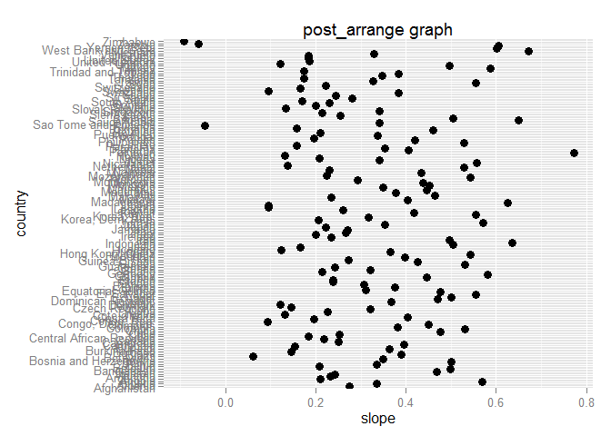

```r
ggplot(post_arrange, aes(x=slope, y=country)) + geom_point(size=3) +
  ggtitle("post_arrange graph")
```

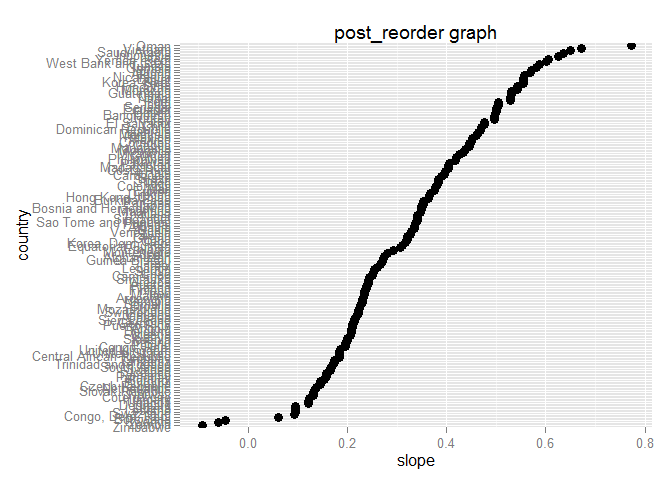

```r
ggplot(post_reorder, aes(x=slope, y=country)) + geom_point(size=3) +
  ggtitle("post_reorder graph")
```

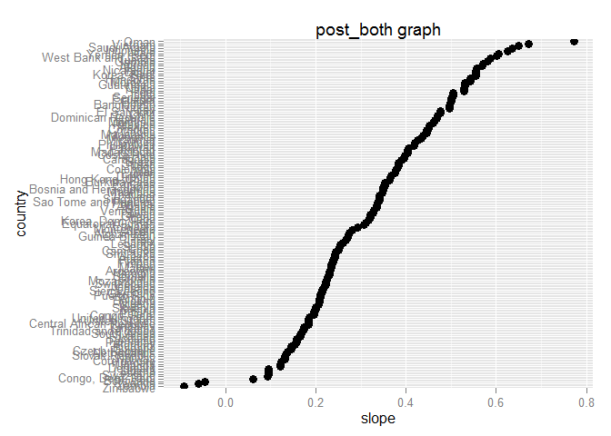

```r
ggplot(post_both, aes(x=slope, y=country)) + geom_point(size=3) +
  ggtitle("post_both graph")
```

Now I finally understand! For `post_arrange`, the table is simply organized by the values of slope. However, `post_reorder` has the part `country = reorder(country, slope)` which **order the country factor based on the slope**. The categorical variable, country, has its levels reordered based on the values of a second variable, slope. In the case of `post_both` the same factor arrangement is made, and the table is arrange by slope. That’s why the tables for `post_both` and `post_arrange` look the same, though the produce different plots because one has its country factor organized to the slope, the other one doesn’t.

## the challenging questions

*If I swap out `arrange(country)` for `arrange(slope)` in `post_both`, what would I get?* This is basically asking what the result would be if we add `arrange(slope)` to the code for `post_reorder`. I think you won’t change the results of the plot nor the table because the levels of country factor are already reorderd based on the slopes. Since the countries are arranged by slopes, they will again be arranged by slopes as well.

```r
post_both2 <- j_coefs %>%
  mutate(country = reorder(country, slope)) %>%
  arrange(slope)
post_both2 %>% head() %>%
  kable(format = "pandoc", caption = "post_both2: head")
```

post_both2: head

[output not shown]

With this in mind, we can see that it’d make more sense to do `arrange()` first if we want to see real effects in the table, and then do `rearrange()` if we want to do certain modeling that requires certain factor levels to be ordered based on numeric variables.